# ISM Tut - Session 6 - Missing Data

Niklas Haffert

# Goal of the session

- Labeling missing data as NA
- Visualizing missing data
- Imputing missing data
- Using imputed data for estimating quantities of interest

# Preparations

### Packages

- haven: read data (STATA format)
- mice: multiple imputation
- mitools: handling data from multiple imputations
- naniar: visualize missing data
- purrr: functional programming
- survey: analyzing survey data
- tidyverse: all tidy operations (dplyr, ggplot2, …)

```r
pacman::p_load(haven, mice, mitools, naniar, purrr, survey, tidyverse)
```

### Data

```r
anes <-
  # read STATA data
  read_dta("../SessionData/anes_2016/anes_timeseries_2016.dta") %>%
  # get correct labels for factor variables
  haven::as_factor(levels = "default") %>%
  # turn factors into characters (better for preprocessig data)
  mutate_if(is.factor, as.character)
```

# Inspecting Missing Data

Create a data frame in which NAs that are not labeled as such are replaced by NAs.

```r
# 1. Preparation: Specify outcomes, which we want to treat as NA
na_strings <-
  c(
    "-9. Refused",
    "-8. Don't know (FTF only)",
    "-1. Inap, 2,-8,-9 in V161005 ",
    "8. Other specify - specified as: DK/don't remember (Web only)",
    "-99. Refused",
    "-89. FTF ONLY: Don't recognize ('don't know who this is')",
    "-88. FTF ONLY: Don't know ('don't know where to rate')",
    "-7. No post data, deleted due to incomplete IW",
    "-6. No post-election interview",
    "998. Don't know (where to rate)",
    "999. Don't recognize (don't know who this is)",
    "-5. Interview breakoff (sufficient partial IW)",
    "-9. RF (-9) in V161193 or V161193a",
    "-8. DK (-8) in V161193 or V161193a (FTF only)",
    "-1. Inap, 2,-8,-9 in V161030/1,4 in V161024x",
    "6. Other specify - specified as: DK",
    "7. Other specify - specified as: RF",
    "8. Other specify - specified as: none/no one/NA",
    "3. Gary Johnson",
    "4. Jill Stein",
    "5. Other candidate {SPECIFY}"
  )

anes_prep <-
  anes %>%
  # 2. Select variables of interest and rename cryptic variable names into something we understand
  select(
    V160201,
    V160102,
    V160202,
    vote_last = V161006,
    obama_score = V161092,
    chr_fund_score = V162095,
    primary_voter = V161021,
    think_gov_spend = V161514,
    undoc_kids = V161195x,
    voting_purpose = V161031
  ) %>%
  # 3. replace predefined missing values strings with NA
  replace_with_na_all(condition = ~ .x %in% na_strings) %>%
  # 4. turn scores to numeric variables
  mutate(obama_score = as.numeric(obama_score),
         chr_fund_score = as.numeric(chr_fund_score)) %>%
  # 5. for optical reasons change labels in voting purpose
  mutate(
    voting_purpose = case_when(
      voting_purpose == "1. Hillary Clinton" ~ "Clinton",
      voting_purpose == "2. Donald Trump" ~ "Trump"
    )
  ) %>%
  # 6. turn character variables back to factors as mice (imputation) needs factors
  mutate_if(is.character, as.factor)
```

Summary for all variables.

```r
anes_prep %>%
  # map applies the summary function to all variables in the data set
  map(summary)
```

```
## $V160201
##    Min. 1st Qu.  Median    Mean 3rd Qu.    Max.
##    1.00   36.00   71.00   69.58  105.00  133.00
##
## $V160102
##    Min. 1st Qu.  Median    Mean 3rd Qu.    Max.
##  0.0000  0.3934  0.7481  0.8541  1.1294  6.4445
##
## $V160202
##    Min. 1st Qu.  Median    Mean 3rd Qu.    Max.
##   1.000   1.000   1.500   1.505   2.000   3.000
##
## $vote_last
##                                                                    1. Barack Obama
##                                                                               1728
##                                                                     2. Mitt Romney
##                                                                               1268
##                                                                   5. Other SPECIFY
##                                                                                 58
## 6. Other specify - specified as:  Did not vote/did not vote for President in 2012
##                                                                                  3
##                                                                               NA's
##                                                                               1213
##
## $obama_score
##    Min. 1st Qu.  Median    Mean 3rd Qu.    Max.    NA's
##    0.00   15.00   60.00   53.06   85.00  100.00      21
##
## $chr_fund_score
##    Min. 1st Qu.  Median    Mean 3rd Qu.    Max.    NA's
##    0.00   31.00   50.00   50.27   70.00  100.00     755
##
## $primary_voter
##      1. Yes, voted in primary or caucus 2. No, didn't vote in primary or caucus
##                                    1882                                    2382
##                                    NA's
##                                       6
##
## $think_gov_spend
##      1. Foreign aid         2. Medicare 3. National defense  4. Social Security
```

[output cut: 8 more lines]

```
##                                               332
##              3. Should send back - favor a little
##                                               112
##          4. Should allow to stay - favor a little
##                                               435
## 5. Should allow to stay - favor a moderate amount
##                                              1437
##      6. Should allow to stay - favor a great deal
##                                              1549
##                                              NA's
##                                                76
##
## $voting_purpose
## Clinton   Trump    NA's
##    1570    1357    1343
```

Summary how many missing values there are per variable.

```r
miss_var_summary(anes_prep)
```

```
## # A tibble: 10 x 3
##    variable        n_miss pct_miss
##    <chr>            <int>    <dbl>
##  1 voting_purpose    1343   31.5
##  2 vote_last         1213   28.4
##  3 chr_fund_score     755   17.7
##  4 think_gov_spend    121    2.83
##  5 undoc_kids          76    1.78
##  6 obama_score         21    0.492
##  7 primary_voter        6    0.141
##  8 V160201              0    0
##  9 V160102              0    0
## 10 V160202              0    0
```

Visualization of the extent of missing data.

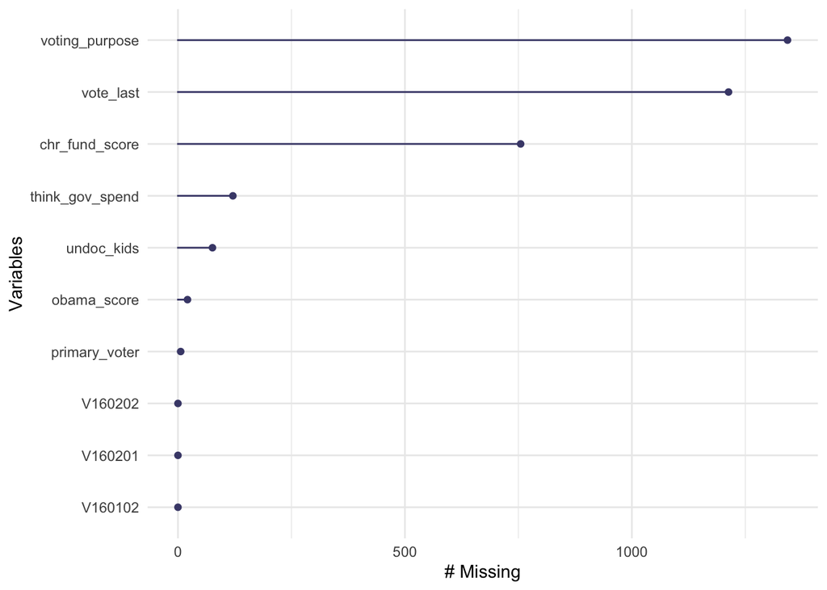

```r
gg_miss_var(anes_prep)
```

Visualization of how the missing values are distributed within the data frame.

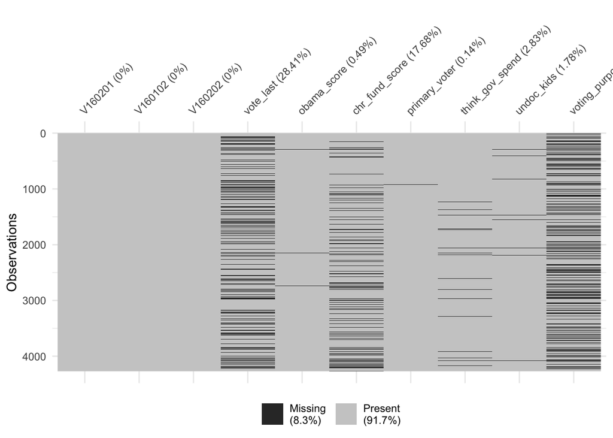

```r
vis_miss(anes_prep)
```

# Imputation

```r
map(anes_prep, class)
```

```
## $V160201
## [1] "numeric"
##
## $V160102
## [1] "numeric"
##
## $V160202
## [1] "numeric"
##
## $vote_last
## [1] "factor"
##
## $obama_score
## [1] "numeric"
##
## $chr_fund_score
## [1] "numeric"
##
## $primary_voter
## [1] "factor"
##
## $think_gov_spend
## [1] "factor"
##
## $undoc_kids
## [1] "factor"
##
## $voting_purpose
## [1] "factor"
```

Based on the anes_prep created data set, we create a predictor matrix. We use the quickpred function, which helps to build a good imputation model for data with many variables. If the correlation between two variables exceeds a threshold value (default 0.1), we include them as predictors.

```r
pred_matrix <- quickpred(anes_prep)

pred_matrix
```

```
##                 V160201 V160102 V160202 vote_last obama_score chr_fund_score
## V160201               0       0       0         0           0              0
## V160102               0       0       0         0           0              0
## V160202               0       0       0         0           0              0
## vote_last             0       0       0         0           1              1
## obama_score           0       0       0         1           0              1
## chr_fund_score        0       1       0         1           1              0
## primary_voter         0       0       0         0           0              0
## think_gov_spend       0       0       0         0           0              0
## undoc_kids            0       0       0         1           1              1
## voting_purpose        0       0       0         1           1              1
##                 primary_voter think_gov_spend undoc_kids voting_purpose
## V160201                     0               0          0              0
## V160102                     0               0          0              0
## V160202                     0               0          0              0
## vote_last                   1               0          1              1
## obama_score                 0               0          1              1
## chr_fund_score              0               0          1              1
## primary_voter               0               0          0              0
## think_gov_spend             0               0          0              1
## undoc_kids                  0               0          0              1
## voting_purpose              1               1          1              0
```

In this step we remove the variables we do not want to use for imputation.

```r
pred_matrix[, c("V160201", "V160102", "V160202")] <- 0

pred_matrix
```

```
##                 V160201 V160102 V160202 vote_last obama_score chr_fund_score
## V160201               0       0       0         0           0              0
## V160102               0       0       0         0           0              0
## V160202               0       0       0         0           0              0
## vote_last             0       0       0         0           1              1
## obama_score           0       0       0         1           0              1
## chr_fund_score        0       0       0         1           1              0
## primary_voter         0       0       0         0           0              0
## think_gov_spend       0       0       0         0           0              0
## undoc_kids            0       0       0         1           1              1
## voting_purpose        0       0       0         1           1              1
##                 primary_voter think_gov_spend undoc_kids voting_purpose
## V160201                     0               0          0              0
## V160102                     0               0          0              0
## V160202                     0               0          0              0
## vote_last                   1               0          1              1
## obama_score                 0               0          1              1
## chr_fund_score              0               0          1              1
## primary_voter               0               0          0              0
## think_gov_spend             0               0          0              1
## undoc_kids                  0               0          0              1
## voting_purpose              1               1          1              0
```

Next, we let us display which methods were used to impute the respective variable. An explanation about the different procedures can be found in the “R Documentation” of the mice package.

```r
imp_meth <-
  mice(anes_prep,
     m = 1,
     maxit = 1,
     predictorMatrix = pred_matrix,
       print = FALSE)$method %>%
  as.vector()

# vector with the imputation methods
imp_meth
```

```
##  [1] ""        ""        ""        "polyreg" "pmm"     "pmm"     "logreg"
##  [8] "polyreg" "polyreg" "logreg"
```

Checking methods.

```r
?mice
```

Changing methods used for prediction.

```r
imp_meth[5:6] <- "norm.predict"
imp_meth
```

```
##  [1] ""             ""             ""             "polyreg"      "norm.predict"
##  [6] "norm.predict" "logreg"       "polyreg"      "polyreg"      "logreg"
```

Imputation with the mice function.

```r
imp <-
  mice(anes_prep,
       # using the methods we specified previously
       method = imp_meth,
       # using the predictor matrix we specified previously
       predictorMatrix = pred_matrix,
       seed = 2020,
       print = FALSE)
```

Create a imputation list which is used for the following analysis. The function complete takes an object of class mids (imp in our case), fills in the missing data, and returns the completed data. map is used to apply complete to all five imputations. imputationList combines data sets into one list.

```r
imp_data <-
  map(seq(imp$m), ~ complete(data = imp)) %>%
  imputationList()
```

# Survey Design Objects

Survey Design Object for all five imputed data frames.

```r
imp_design <-
  svydesign(
    ~ V160202 ,
    strata = ~ V160201 ,
    data = imp_data ,
    weights = ~ V160102 ,
    nest = TRUE
  )
```

Survey Design Object for unimputed data.

```r
unimp_design <-
  svydesign(
    ~ V160202 ,
    strata = ~ V160201 ,
    data = anes_prep ,
    weights = ~ V160102 ,
    nest = TRUE
  )
```

# Estimates

## Mean

Mean for voting_purpose (imputed data).

```r
imp_results <- with(imp_design, svymean(~ voting_purpose))

imp_results %>%
  MIcombine() %>%
  summary()
```

```
## Multiple imputation results:
##       with(imp_design, svymean(~voting_purpose))
##       MIcombine.default(.)
##                         results         se    (lower    upper) missInfo
## voting_purposeClinton 0.5468099 0.01166655 0.5239439 0.5696760      0 %
## voting_purposeTrump   0.4531901 0.01166655 0.4303240 0.4760561      0 %
```

Mean for voting_purpose (data without imputation).

```r
svymean(~ voting_purpose , unimp_design, na.rm = TRUE)
```

```
##                          mean     SE
## voting_purposeClinton 0.54844 0.0137
## voting_purposeTrump   0.45156 0.0137
```

## Mean by group

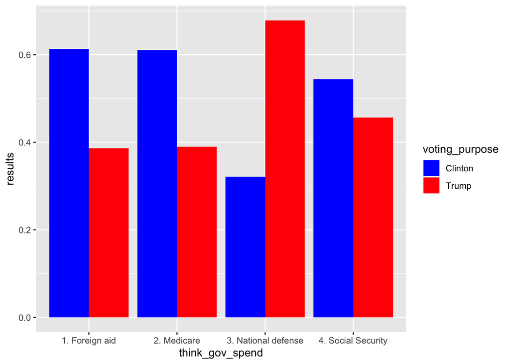

```r
with(
  imp_design,
  svyby(
    formula = ~ voting_purpose,
    by = ~ think_gov_spend,
    FUN = svymean
  )
) %>%
  MIcombine() %>%
  summary() %>%
  mutate(names = rownames(.)) %>%
  separate(names, c("think_gov_spend", "voting_purpose"), sep = ":") %>%
  mutate(voting_purpose = str_remove(voting_purpose, "voting_purpose")) %>%
  ggplot(aes(
    x = think_gov_spend,
    y = results,
    group = voting_purpose,
    fill = voting_purpose
  )) +
  geom_bar(position = "dodge", stat = "identity") +
  scale_fill_manual(values = c("blue", "red"))
```

Same as before but with unimputed data.

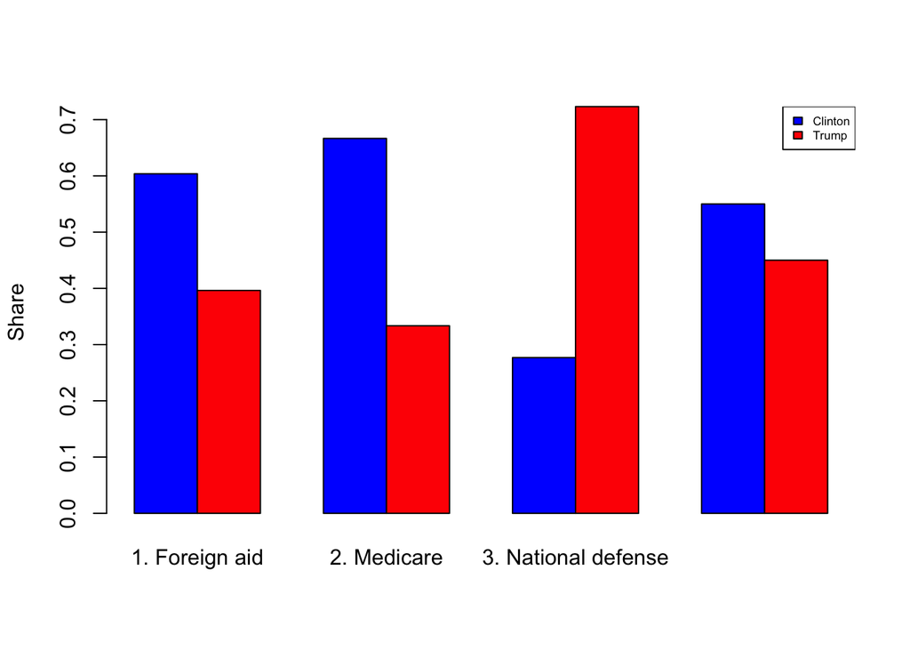

```r
bar_vote <-
  svyby(
    formula = ~ voting_purpose,
    by =  ~ think_gov_spend,
    design = unimp_design,
    FUN = svymean,
    na.rm = TRUE
  )
barplot(bar_vote, ylab = "Share", col = c("blue", "red"))
legend(
  "topright",
  legend = c("Clinton", "Trump"),
  fill = c("blue", "red"),
  cex = 0.55
)
```

## Regression

Logistic Regression with voting purpose as dependent variable and knowledge on government spending, opinion on illegal immigrant children and christian fundamentalist score as independent variables, using imputed data.

```r
with(
  imp_design,
  svyglm(
    voting_purpose ~ think_gov_spend + undoc_kids + chr_fund_score,
    family = stats::binomial()
  )
) %>%
  MIcombine() %>%
  summary()
```

```
## Multiple imputation results:
##       with(imp_design, svyglm(voting_purpose ~ think_gov_spend + undoc_kids +
##     chr_fund_score, family = stats::binomial()))
##       MIcombine.default(.)
##                                                                 results
## (Intercept)                                                  0.08202973
## think_gov_spend2. Medicare                                  -0.01975373
## think_gov_spend3. National defense                           0.96914425
## think_gov_spend4. Social Security                            0.19970516
## undoc_kids2. Should send back - favor a moderate amount     -0.16680947
## undoc_kids3. Should send back - favor a little              -0.16720311
## undoc_kids4. Should allow to stay - favor a little          -0.99342760
## undoc_kids5. Should allow to stay - favor a moderate amount -1.39191220
## undoc_kids6. Should allow to stay - favor a great deal      -2.43588653
## chr_fund_score                                               0.01918975
##                                                                      se
## (Intercept)                                                 0.207738183
## think_gov_spend2. Medicare                                  0.144439472
## think_gov_spend3. National defense                          0.148104010
## think_gov_spend4. Social Security                           0.108370366
## undoc_kids2. Should send back - favor a moderate amount     0.257851593
## undoc_kids3. Should send back - favor a little              0.313183198
## undoc_kids4. Should allow to stay - favor a little          0.230418692
## undoc_kids5. Should allow to stay - favor a moderate amount 0.196684996
## undoc_kids6. Should allow to stay - favor a great deal      0.208399586
## chr_fund_score                                              0.001719171
##                                                                  (lower
## (Intercept)                                                 -0.32512963
## think_gov_spend2. Medicare                                  -0.30284989
## think_gov_spend3. National defense                           0.67886573
## think_gov_spend4. Social Security                           -0.01269686
## undoc_kids2. Should send back - favor a moderate amount     -0.67218930
## undoc_kids3. Should send back - favor a little              -0.78103090
## undoc_kids4. Should allow to stay - favor a little          -1.44503994
## undoc_kids5. Should allow to stay - favor a moderate amount -1.77740771
## undoc_kids6. Should allow to stay - favor a great deal      -2.84434221
## chr_fund_score                                               0.01582023
##                                                                  upper)
## (Intercept)                                                  0.48918909
## think_gov_spend2. Medicare                                   0.26334244
## think_gov_spend3. National defense                           1.25942278
## think_gov_spend4. Social Security                            0.41210717
## undoc_kids2. Should send back - favor a moderate amount      0.33857037
## undoc_kids3. Should send back - favor a little               0.44662468
## undoc_kids4. Should allow to stay - favor a little          -0.54181527
## undoc_kids5. Should allow to stay - favor a moderate amount -1.00641669
## undoc_kids6. Should allow to stay - favor a great deal      -2.02743085
## chr_fund_score                                               0.02255926
##                                                             missInfo
## (Intercept)                                                      0 %
## think_gov_spend2. Medicare                                       0 %
## think_gov_spend3. National defense                               0 %
## think_gov_spend4. Social Security                                0 %
## undoc_kids2. Should send back - favor a moderate amount          0 %
## undoc_kids3. Should send back - favor a little                   0 %
## undoc_kids4. Should allow to stay - favor a little               0 %
## undoc_kids5. Should allow to stay - favor a moderate amount      0 %
## undoc_kids6. Should allow to stay - favor a great deal           0 %
## chr_fund_score                                                   0 %
```

Same regression but with unimputed data.

```r
svyglm(
      voting_purpose ~ think_gov_spend + undoc_kids + chr_fund_score,
      family = stats::binomial(),
      design = unimp_design
    ) %>%
  summary()
```

```
##
## Call:
## svyglm(formula = voting_purpose ~ think_gov_spend + undoc_kids +
##     chr_fund_score, design = unimp_design, family = stats::binomial())
##
## Survey design:
## svydesign(~V160202, strata = ~V160201, data = anes_prep, weights = ~V160102,
##     nest = TRUE)
##
## Coefficients:
##                                                              Estimate
## (Intercept)                                                 -0.006693
## think_gov_spend2. Medicare                                  -0.396286
## think_gov_spend3. National defense                           1.008236
## think_gov_spend4. Social Security                           -0.006751
## undoc_kids2. Should send back - favor a moderate amount     -0.202809
## undoc_kids3. Should send back - favor a little              -0.518736
## undoc_kids4. Should allow to stay - favor a little          -0.995034
## undoc_kids5. Should allow to stay - favor a moderate amount -1.384896
## undoc_kids6. Should allow to stay - favor a great deal      -2.699467
## chr_fund_score                                               0.024309
##                                                             Std. Error t value
## (Intercept)                                                   0.253705  -0.026
## think_gov_spend2. Medicare                                    0.170151  -2.329
## think_gov_spend3. National defense                            0.178926   5.635
## think_gov_spend4. Social Security                             0.137812  -0.049
## undoc_kids2. Should send back - favor a moderate amount       0.298855  -0.679
## undoc_kids3. Should send back - favor a little                0.360813  -1.438
## undoc_kids4. Should allow to stay - favor a little            0.295683  -3.365
## undoc_kids5. Should allow to stay - favor a moderate amount   0.250651  -5.525
## undoc_kids6. Should allow to stay - favor a great deal        0.261736 -10.314
## chr_fund_score                                                0.002078  11.700
##                                                             Pr(>|t|)
## (Intercept)                                                  0.97900
## think_gov_spend2. Medicare                                   0.02148 *
## think_gov_spend3. National defense                          1.12e-07 ***
## think_gov_spend4. Social Security                            0.96101
## undoc_kids2. Should send back - favor a moderate amount      0.49864
## undoc_kids3. Should send back - favor a little               0.15304
## undoc_kids4. Should allow to stay - favor a little           0.00102 **
## undoc_kids5. Should allow to stay - favor a moderate amount 1.85e-07 ***
## undoc_kids6. Should allow to stay - favor a great deal       < 2e-16 ***
## chr_fund_score                                               < 2e-16 ***
## ---
## Signif. codes:  0 '***' 0.001 '**' 0.01 '*' 0.05 '.' 0.1 ' ' 1
##
## (Dispersion parameter for binomial family taken to be 1.135857)
##
## Number of Fisher Scoring iterations: 4
```